# R Notebook

# 3 datasets by year

```r
d2015 = df %>% filter(arrival_date_year==2015)
d2016 = df %>% filter(arrival_date_year==2016)
d2017 = df %>% filter(arrival_date_year==2017)
```

## Predicting Model for Booking Cancellations

# Creation of Room Given and Cancellation Tendency

```r
#reserved_room_type and assigned_room_type is similar feature. We can combine these into one feature only.
#We will put 1 if the guest was assigned to the same room that they reserved and 0 if its different.
df2 <- df
df2["room_given"]=0
df2 <- df2 %>% mutate(room_given = if_else(reserved_room_type == assigned_room_type, 1, 0))

#previous_cancellations and previous_bookings_not_canceled describes about cancellation. We can combine these into one feature only. We will put 1 if previous_cancellations is higher than previous_bookings_not_canceled and 0 if its not
df2 <- df2 %>%
  mutate(cancellation_tendency = if_else(previous_cancellations > previous_bookings_not_canceled, 1, 0))

df2 <- subset(df2, select = -c(reserved_room_type, assigned_room_type,previous_cancellations,
                               previous_bookings_not_canceled, country))
```

#Data Splitting

#In this section, we have partitioned the data into train and test sets with 70-30 ratio respectively. #The training set will be used for model development where the machine learning models will identify #the cancellation pattern while the test set will be utilised to evaluate the performance of our models.

```r
set.seed(50)
df2$is_canceled <-as.factor(df2$is_canceled)
trainIndex <- createDataPartition(df2$is_canceled, p = .7,list = FALSE,times = 1)
train_data<- df2[ trainIndex,]
test_data <- df2[-trainIndex,]
table(train_data$is_canceled)
```

```
    0     1
51277 30748
```

#DATA RESAMPLING

#Most of data in real-world are imbalance in nature. This occurs when the distribution of the target class is not uniform among the different class levels. For classifier, this will lead to a huge challenge in detecting the class of interest which resides on the minority class. For our case, we are interested in knowing whether the guest will cancel their hotel reservation or not, in which the positive class (cancel reservation) is in minority group.

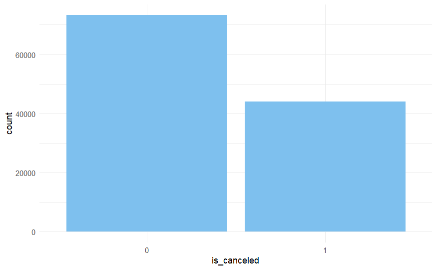

```r
# Barplot
ggplot(df2, aes(x=is_canceled)) +
  geom_bar(fill="skyblue2") +theme_minimal()
```

#To handle class imbalanced problem, we used downSample. downSample will randomly eliminate the sample from majority class to make the class distributions equal.

```r
set.seed(50)

#DownSampling
train_data_down<-downSample(x=train_data[,-ncol(train_data)],
                  y=train_data$is_canceled)
table(train_data_down$is_canceled)
```

```
    0     1
30748 30748
```

```r
train_data_down <- subset(train_data_down, select = -c(Class))
```

#MODEL DEVELOPMENT

# Logistic Regression on train data

```r
modelLR = glm(is_canceled ~ . -total_costs , family= "binomial", data = train_data)
summary(modelLR)
```

```
Call:
glm(formula = is_canceled ~ . - total_costs, family = "binomial",
    data = train_data)

Coefficients:
                               Estimate Std. Error z value Pr(>|z|)
(Intercept)                  -5.955e+01  4.487e+01  -1.327 0.184384
hotelResort Hotel             1.506e-01  2.316e-02   6.502 7.94e-11 ***
lead_time                     3.676e-03  1.307e-04  28.124  < 2e-16 ***
arrival_date_year             2.870e-02  2.217e-02   1.295 0.195474
arrival_date_monthAugust      2.021e+00  4.356e-01   4.640 3.49e-06 ***
arrival_date_monthDecember    4.381e+00  8.691e-01   5.041 4.63e-07 ***
arrival_date_monthFebruary   -9.509e-01  2.179e-01  -4.365 1.27e-05 ***
arrival_date_monthJanuary    -1.592e+00  3.276e-01  -4.860 1.18e-06 ***
arrival_date_monthJuly        1.352e+00  3.254e-01   4.155 3.26e-05 ***
arrival_date_monthJune        9.225e-01  2.219e-01   4.158 3.22e-05 ***
arrival_date_monthMarch      -6.562e-01  1.193e-01  -5.499 3.81e-08 ***
arrival_date_monthMay         4.087e-01  1.159e-01   3.526 0.000422 ***
arrival_date_monthNovember    3.750e+00  7.643e-01   4.907 9.26e-07 ***
arrival_date_monthOctober     3.188e+00  6.541e-01   4.873 1.10e-06 ***
arrival_date_monthSeptember   2.563e+00  5.475e-01   4.680 2.87e-06 ***
arrival_date_week_number     -1.213e-01  2.493e-02  -4.866 1.14e-06 ***
arrival_date_day_of_month     1.702e-02  3.743e-03   4.548 5.42e-06 ***
stays_in_weekend_nights       2.785e-02  1.102e-02   2.528 0.011467 *
stays_in_week_nights          3.632e-02  5.828e-03   6.232 4.60e-10 ***
adults                        7.808e-02  2.253e-02   3.465 0.000530 ***
children                      9.539e-02  2.436e-02   3.916 8.99e-05 ***
babies                        2.368e-01  1.002e-01   2.363 0.018143 *
mealFB                        7.058e-01  1.345e-01   5.246 1.55e-07 ***
mealHB                       -1.016e-01  3.323e-02  -3.056 0.002240 **
mealSC                        4.493e-02  2.948e-02   1.524 0.127475
market_segmentComplementary  -5.580e-01  6.732e-01  -0.829 0.407198
market_segmentCorporate      -2.802e-01  2.167e-01  -1.293 0.196107
market_segmentDirect         -4.219e-01  2.484e-01  -1.698 0.089438 .
market_segmentGroups         -4.092e-01  2.325e-01  -1.760 0.078402 .
market_segmentOffline TA/TO  -9.656e-01  2.334e-01  -4.136 3.53e-05 ***
market_segmentOnline TA       3.302e-01  2.327e-01   1.419 0.156013
distribution_channelDirect   -9.413e-01  1.254e-01  -7.506 6.12e-14 ***
distribution_channelGDS      -1.322e+00  2.359e-01  -5.603 2.10e-08 ***
distribution_channelTA/TO    -4.582e-01  9.713e-02  -4.718 2.39e-06 ***
```

[output cut: 10 more lines]

```
total_of_special_requests    -7.274e-01  1.417e-02 -51.324  < 2e-16 ***
is_agent                     -1.427e-01  5.145e-02  -2.773 0.005560 **
is_company                   -1.112e+00  9.552e-02 -11.642  < 2e-16 ***
room_given                    1.822e+00  5.038e-02  36.171  < 2e-16 ***
cancellation_tendency         5.694e+00  2.152e-01  26.462  < 2e-16 ***
---
Signif. codes:  0 ‘***’ 0.001 ‘**’ 0.01 ‘*’ 0.05 ‘.’ 0.1 ‘ ’ 1

(Dispersion parameter for binomial family taken to be 1)

    Null deviance: 108518  on 82024  degrees of freedom
Residual deviance:  67027  on 81976  degrees of freedom
AIC: 67125

Number of Fisher Scoring iterations: 16
```

```r
important = varImp(modelLR, scale = FALSE, top=10)
important %>% arrange(desc(important$Overall))
```

|  | Overall |
| --- | --- |
| total_of_special_requests | 51.3243099 |
| deposit_typeNon Refund | 42.1027922 |
| room_given | 36.1707510 |
| lead_time | 28.1237090 |
| cancellation_tendency | 26.4617563 |
| booking_changes | 17.7634347 |
| customer_typeTransient | 14.9339603 |
| adr | 12.9114309 |
| is_company | 11.6416152 |
| is_repeated_guest | 9.7639084 |

[output cut: 38 more lines]

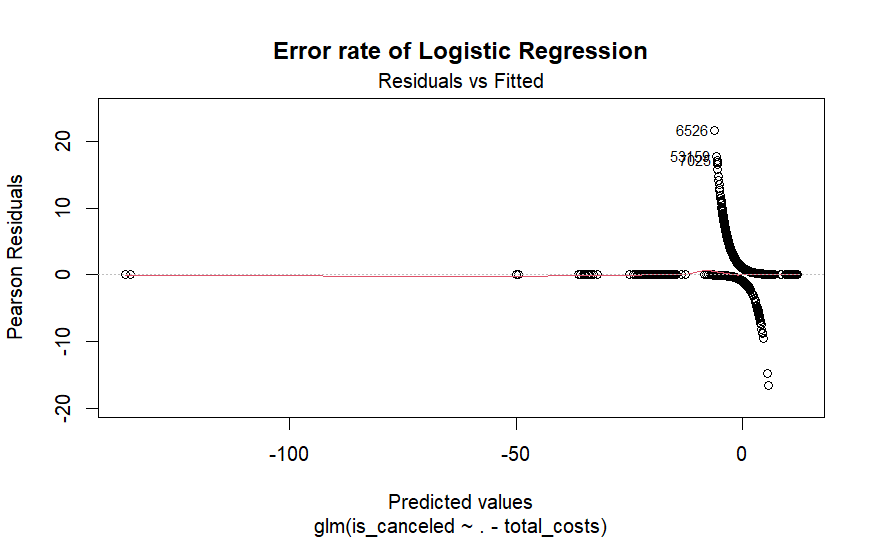

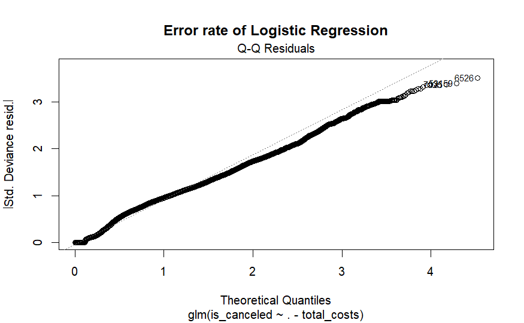

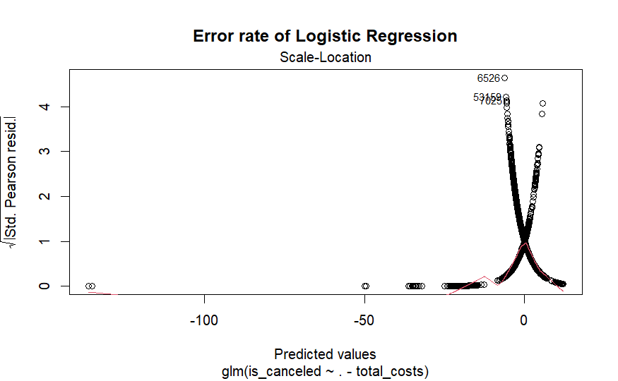

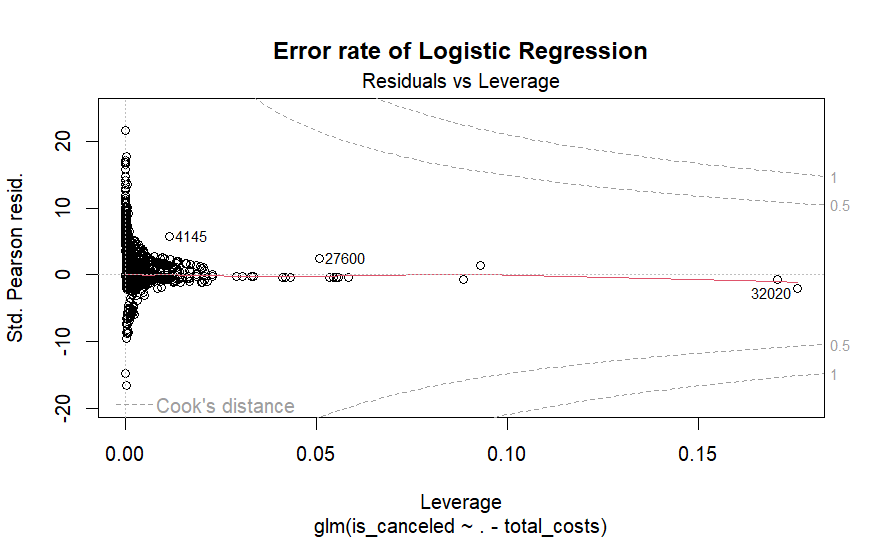

```r
#plot the train data model
plot(modelLR, main = "Error rate of Logistic Regression")
```

```r
predictionLR = predict(modelLR, newdata = test_data, type = "response")
predictionLR = ifelse(predictionLR < 0.3, 0, 1)

AUCLR = auc(test_data$is_canceled,as.numeric(predictionLR))
AUCLR
```

```
Area under the curve: 0.7572
```

```r
tab_Test = table(actual=test_data$is_canceled, predicted=predictionLR);
confusionMatrix(tab_Test, mode = "everything", positive = "1")
```

```
Confusion Matrix and Statistics

      predicted
actual     0     1
     0 15461  6514
     1  2494 10683

               Accuracy : 0.7437
                 95% CI : (0.7391, 0.7483)
    No Information Rate : 0.5108
    P-Value [Acc > NIR] : < 2.2e-16

                  Kappa : 0.4847

 Mcnemar's Test P-Value : < 2.2e-16

            Sensitivity : 0.6212
            Specificity : 0.8611
         Pos Pred Value : 0.8107
         Neg Pred Value : 0.7036
              Precision : 0.8107
                 Recall : 0.6212
                     F1 : 0.7034
             Prevalence : 0.4892
         Detection Rate : 0.3039
   Detection Prevalence : 0.3749
      Balanced Accuracy : 0.7412

       'Positive' Class : 1
```

# Logistic Regression on train data down

```r
modelLR_down = glm(is_canceled ~ . -total_costs , family= "binomial", data = train_data_down)
summary(modelLR_down)
```

```
Call:
glm(formula = is_canceled ~ . - total_costs, family = "binomial",
    data = train_data_down)

Coefficients:
                               Estimate Std. Error z value Pr(>|z|)
(Intercept)                   5.283e+02  4.611e+01  11.455  < 2e-16 ***
hotelResort Hotel             6.758e-02  2.499e-02   2.704 0.006844 **
lead_time                     4.410e-03  1.399e-04  31.530  < 2e-16 ***
arrival_date_year            -2.612e-01  2.279e-02 -11.460  < 2e-16 ***
arrival_date_monthAugust      5.033e+00  4.620e-01  10.894  < 2e-16 ***
arrival_date_monthDecember    1.044e+01  9.227e-01  11.311  < 2e-16 ***
arrival_date_monthFebruary   -2.315e+00  2.314e-01 -10.005  < 2e-16 ***
arrival_date_monthJanuary    -3.732e+00  3.479e-01 -10.727  < 2e-16 ***
arrival_date_monthJuly        3.664e+00  3.453e-01  10.611  < 2e-16 ***
arrival_date_monthJune        2.398e+00  2.362e-01  10.153  < 2e-16 ***
arrival_date_monthMarch      -1.420e+00  1.274e-01 -11.145  < 2e-16 ***
arrival_date_monthMay         1.166e+00  1.241e-01   9.394  < 2e-16 ***
arrival_date_monthNovember    8.959e+00  8.113e-01  11.043  < 2e-16 ***
arrival_date_monthOctober     7.684e+00  6.944e-01  11.066  < 2e-16 ***
arrival_date_monthSeptember   6.285e+00  5.809e-01  10.819  < 2e-16 ***
arrival_date_week_number     -2.957e-01  2.646e-02 -11.176  < 2e-16 ***
arrival_date_day_of_month     4.115e-02  3.983e-03  10.331  < 2e-16 ***
stays_in_weekend_nights       2.276e-02  1.190e-02   1.913 0.055731 .
stays_in_week_nights          2.810e-02  6.285e-03   4.472 7.77e-06 ***
adults                        7.322e-02  2.447e-02   2.993 0.002766 **
children                      1.021e-01  2.740e-02   3.728 0.000193 ***
babies                        2.186e-01  1.171e-01   1.867 0.061869 .
mealFB                        5.235e-01  1.491e-01   3.510 0.000449 ***
mealHB                       -1.452e-01  3.543e-02  -4.099 4.15e-05 ***
mealSC                        2.713e-02  3.297e-02   0.823 0.410605
market_segmentComplementary  -7.522e-01  7.077e-01  -1.063 0.287802
market_segmentCorporate      -2.659e-01  2.197e-01  -1.210 0.226152
market_segmentDirect         -3.711e-01  2.559e-01  -1.450 0.147015
market_segmentGroups         -2.852e-01  2.388e-01  -1.194 0.232344
market_segmentOffline TA/TO  -1.011e+00  2.394e-01  -4.222 2.42e-05 ***
market_segmentOnline TA       2.729e-01  2.389e-01   1.142 0.253316
distribution_channelDirect   -9.543e-01  1.331e-01  -7.170 7.51e-13 ***
distribution_channelGDS      -1.106e+00  2.568e-01  -4.307 1.66e-05 ***
distribution_channelTA/TO    -4.048e-01  1.033e-01  -3.919 8.90e-05 ***
```

[output cut: 9 more lines]

```
required_car_parking_spaces  -1.690e+01  6.187e+01  -0.273 0.784730
total_of_special_requests    -7.005e-01  1.508e-02 -46.435  < 2e-16 ***
is_agent                     -9.645e-02  5.392e-02  -1.789 0.073646 .
is_company                   -1.076e+00  1.009e-01 -10.661  < 2e-16 ***
room_given                    1.930e+00  5.133e-02  37.602  < 2e-16 ***
---
Signif. codes:  0 ‘***’ 0.001 ‘**’ 0.01 ‘*’ 0.05 ‘.’ 0.1 ‘ ’ 1

(Dispersion parameter for binomial family taken to be 1)

    Null deviance: 85252  on 61495  degrees of freedom
Residual deviance: 55762  on 61448  degrees of freedom
AIC: 55858

Number of Fisher Scoring iterations: 16
```

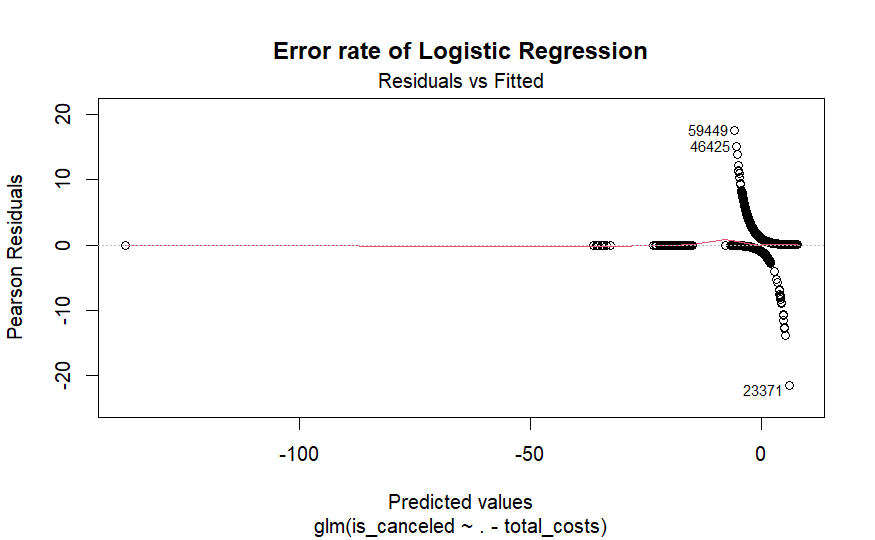

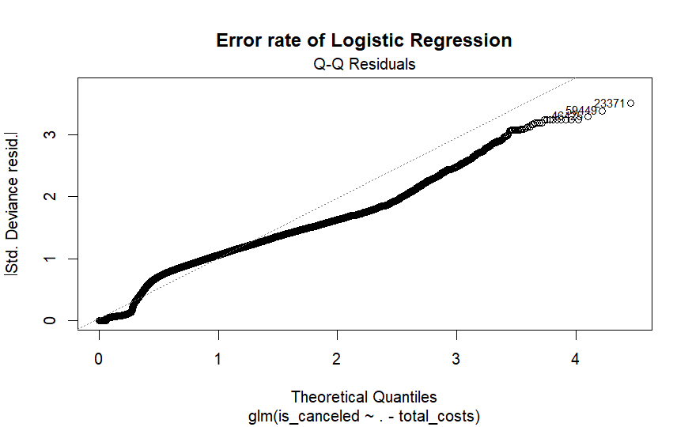

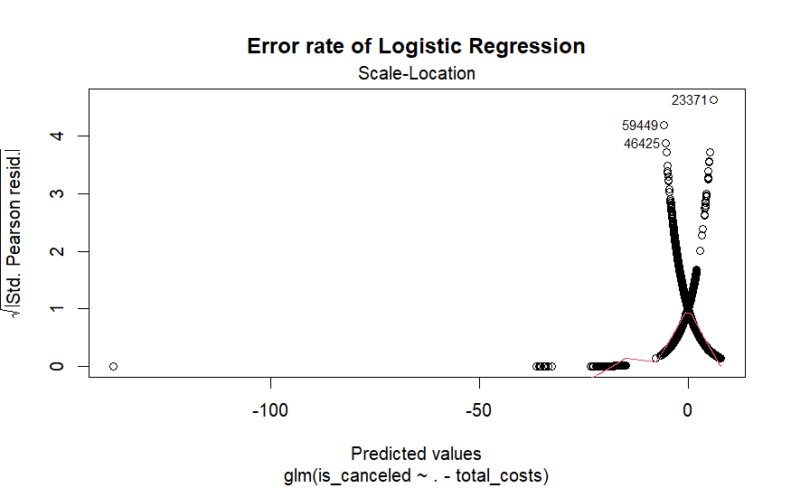

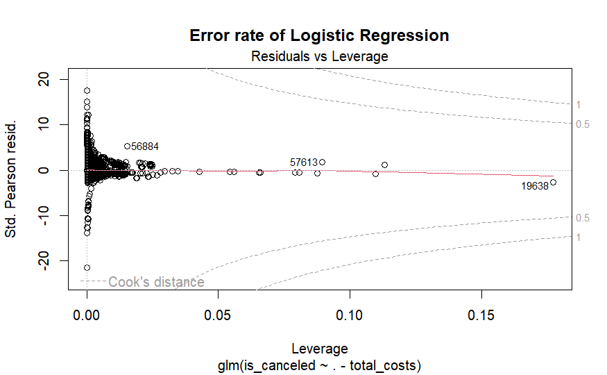

```r
#plot the train data model
plot(modelLR_down, main = "Error rate of Logistic Regression")
```

```r
predictionLR_down = predict(modelLR_down, newdata = test_data, type = "response")
predictionLR_down = ifelse(predictionLR_down < 0.3, 0, 1)

AUCLR_down = auc(test_data$is_canceled,as.numeric(predictionLR_down))
AUCLR_down
```

```
Area under the curve: 0.6963
```

```r
tab_Test = table(actual=test_data$is_canceled, predicted=predictionLR_down);
confusionMatrix(tab_Test, mode = "everything", positive = "1")
```

```
Confusion Matrix and Statistics

      predicted
actual     0     1
     0 10730 11245
     1  1261 11916

               Accuracy : 0.6442
                 95% CI : (0.6392, 0.6492)
    No Information Rate : 0.6589
    P-Value [Acc > NIR] : 1

                  Kappa : 0.3409

 Mcnemar's Test P-Value : <2e-16

            Sensitivity : 0.5145
            Specificity : 0.8948
         Pos Pred Value : 0.9043
         Neg Pred Value : 0.4883
              Precision : 0.9043
                 Recall : 0.5145
                     F1 : 0.6558
             Prevalence : 0.6589
         Detection Rate : 0.3390
   Detection Prevalence : 0.3749
      Balanced Accuracy : 0.7047

       'Positive' Class : 1
```

# Dalex for Log Regression train data

```r
df2$is_canceled = as.vector(as.numeric(as.character(df2$is_canceled)))

df_exLR = explain(modelLR,
                data  = df2,
                y     = df2$is_canceled,
                label = "Logistic Regression")
```

```
Preparation of a new explainer is initiated
  -> model label       :  Logistic Regression
  -> data              :  117177  rows  28  cols
  -> data              :  tibble converted into a data.frame
  -> target variable   :  117177  values
  -> predict function  :  yhat.glm  will be used (  default  )
  -> predicted values  :  No value for predict function target column. (  default  )
  -> model_info        :  package stats , ver. 4.4.1 , task classification (  default  )
  -> predicted values  :  numerical, min =  2.220446e-16 , mean =  0.3740142 , max =  1
  -> residual function :  difference between y and yhat (  default  )
  -> residuals         :  numerical, min =  -0.996377 , mean =  0.0008460091 , max =  0.9978611
  A new explainer has been created!
```

```r
# instance level
(single_row = df2[1,])
```

| hotel | is_canceled | lead_time | arrival_date_year | arrival_date_month | arrival_date_week_number | arrival_date_day_of_month | stays_in_weekend_nights | stays_in_week_nights | adults | children | babies | meal | market_segment | distribution_channel | is_repeated_guest | booking_changes | deposit_type | days_in_waiting_list | customer_type | adr | required_car_parking_spaces | total_of_special_requests | is_agent | is_company | total_costs | room_given | cancellation_tendency |
| --- | --- | --- | --- | --- | --- | --- | --- | --- | --- | --- | --- | --- | --- | --- | --- | --- | --- | --- | --- | --- | --- | --- | --- | --- | --- | --- | --- |
| Resort Hotel | 0 | 7 | 2015 | July | 27 | 1 | 0 | 1 | 1 | 0 | 0 | BB | Direct | Direct | 0 | 0 | No Deposit | 0 | Transient | 75 | 0 | 0 | 0 | 0 | 75 | 0 | 0 |

```r
# prediction
df_exLR %>% predict(single_row)
```

```
         1
0.03573334
```

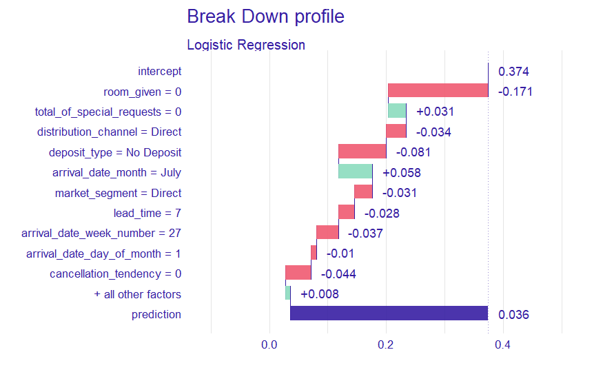

```r
# prediction parts
plot(predict_parts(df_exLR, new_observation = single_row))
```

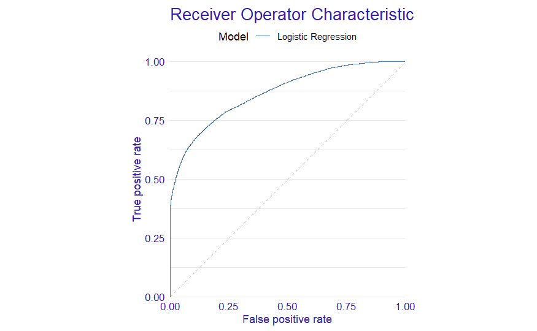

```r
plot(model_performance(df_exLR), geom = "roc")
```

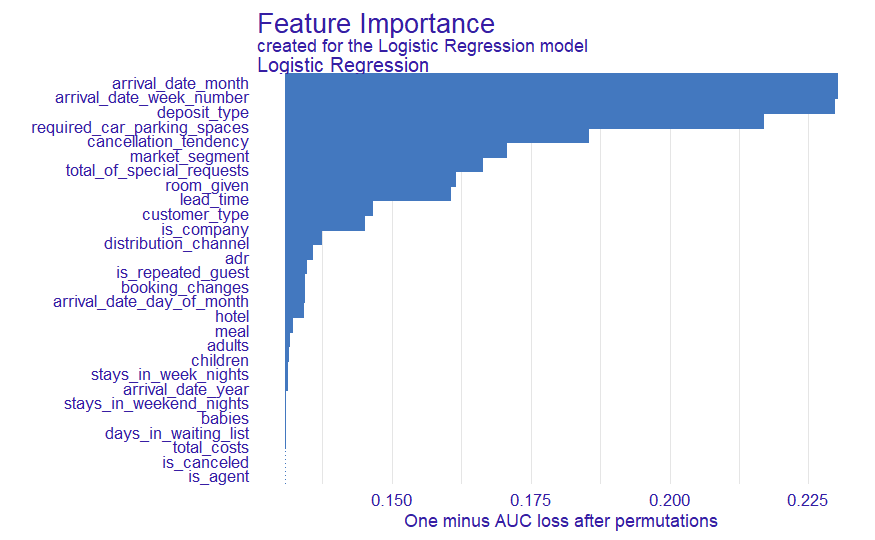

```r
plot(model_parts(df_exLR), show_boxplots = FALSE)
```

# Dalex for LR train data down

```r
df_exLR_down = explain(modelLR_down,
                data  = df2,
                y     = df2$is_canceled,
                label = "Logistic Regression")
```

```
Preparation of a new explainer is initiated
  -> model label       :  Logistic Regression
  -> data              :  117177  rows  28  cols
  -> data              :  tibble converted into a data.frame
  -> target variable   :  117177  values
  -> predict function  :  yhat.glm  will be used (  default  )
  -> predicted values  :  No value for predict function target column. (  default  )
  -> model_info        :  package stats , ver. 4.4.1 , task classification (  default  )
  -> predicted values  :  numerical, min =  2.220446e-16 , mean =  0.452225 , max =  1
  -> residual function :  difference between y and yhat (  default  )
  -> residuals         :  numerical, min =  -0.9978342 , mean =  -0.07736479 , max =  0.9967491
  A new explainer has been created!
```

```r
# instance level
(single_row = df2[1,])
```

| hotel | is_canceled | lead_time | arrival_date_year | arrival_date_month | arrival_date_week_number | arrival_date_day_of_month | stays_in_weekend_nights | stays_in_week_nights | adults | children | babies | meal | market_segment | distribution_channel | is_repeated_guest | booking_changes | deposit_type | days_in_waiting_list | customer_type | adr | required_car_parking_spaces | total_of_special_requests | is_agent | is_company | total_costs | room_given | cancellation_tendency |
| --- | --- | --- | --- | --- | --- | --- | --- | --- | --- | --- | --- | --- | --- | --- | --- | --- | --- | --- | --- | --- | --- | --- | --- | --- | --- | --- | --- |
| Resort Hotel | 0 | 7 | 2015 | July | 27 | 1 | 0 | 1 | 1 | 0 | 0 | BB | Direct | Direct | 0 | 0 | No Deposit | 0 | Transient | 75 | 0 | 0 | 0 | 0 | 75 | 0 | 0 |

```r
# prediction
df_exLR_down %>% predict(single_row)
```

```
         1
0.07244853
```

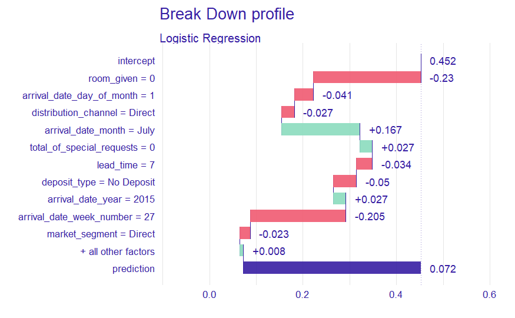

```r
# prediction parts
plot(predict_parts(df_exLR_down, new_observation = single_row))
```

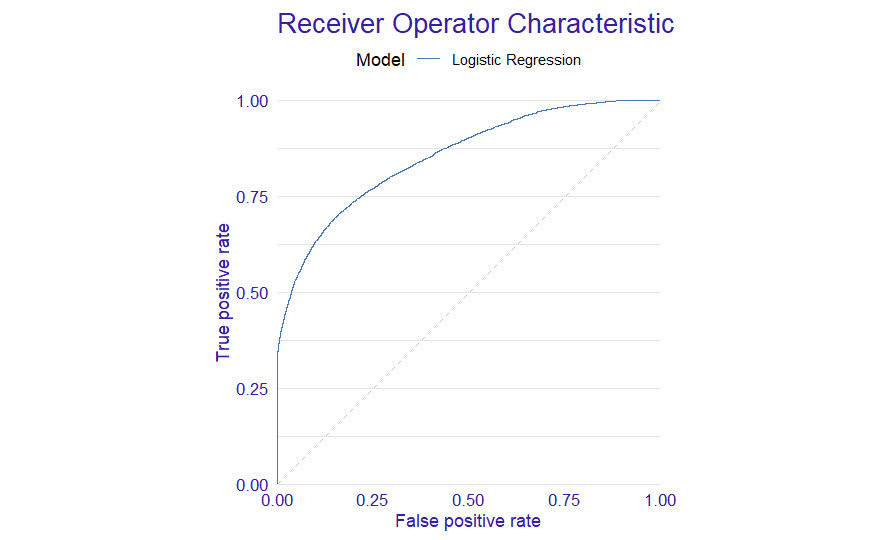

```r
plot(model_performance(df_exLR_down), geom = "roc")
```

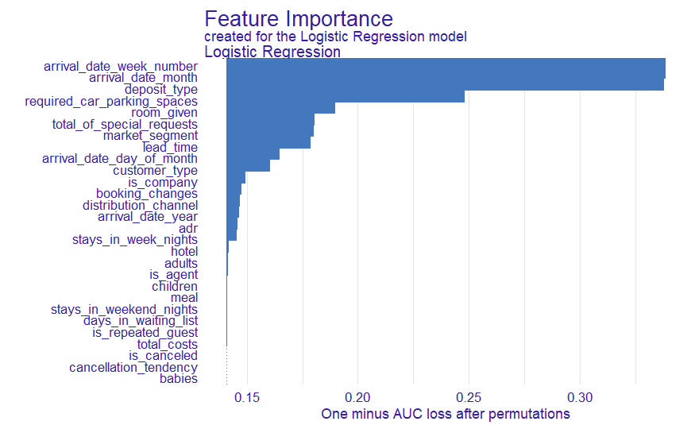

```r
plot(model_parts(df_exLR_down), show_boxplots = FALSE)
```

# Decision Tree

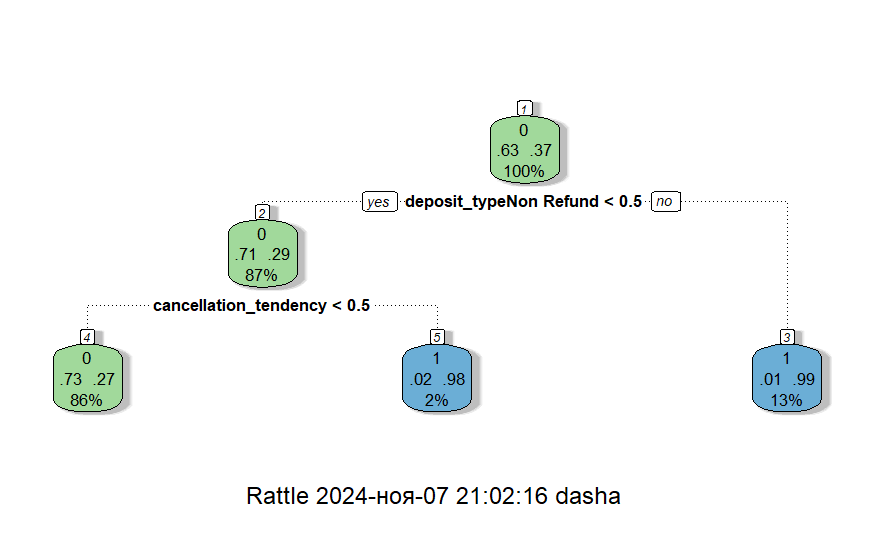

```r
modelDT2 = train(is_canceled ~ . -total_costs , method= "rpart", data = train_data)
predictionsDT2 = predict(modelDT2, newdata = test_data)
# plotting tree
fancyRpartPlot(modelDT2$finalModel)
```

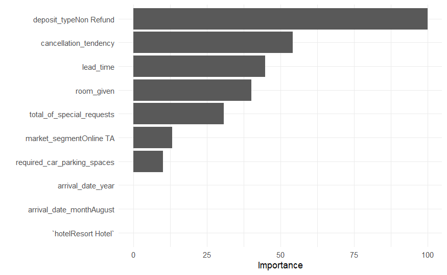

```r
vip(modelDT2)+theme_minimal()
```

```r
AUCDT = auc(test_data$is_canceled,as.numeric(predictionsDT2))
AUCDT
```

```
Area under the curve: 0.685
```

```r
tab_Test = table(actual=test_data$is_canceled, predicted=predictionsDT2);
confusionMatrix(tab_Test, mode = "everything", positive = "1")
```

```
Confusion Matrix and Statistics

      predicted
actual     0     1
     0 21934    41
     1  8276  4901

               Accuracy : 0.7634
                 95% CI : (0.7589, 0.7678)
    No Information Rate : 0.8594
    P-Value [Acc > NIR] : 1

                  Kappa : 0.423

 Mcnemar's Test P-Value : <2e-16

            Sensitivity : 0.9917
            Specificity : 0.7261
         Pos Pred Value : 0.3719
         Neg Pred Value : 0.9981
              Precision : 0.3719
                 Recall : 0.9917
                     F1 : 0.5410
             Prevalence : 0.1406
         Detection Rate : 0.1394
   Detection Prevalence : 0.3749
      Balanced Accuracy : 0.8589

       'Positive' Class : 1
```

# Dalex for DT

```r
df_exDT = explain(modelDT2,
                data  = df2,
                y     = df2$is_canceled,
                label = "Decision Tree")
```

```
Preparation of a new explainer is initiated
  -> model label       :  Decision Tree
  -> data              :  117177  rows  28  cols
  -> data              :  tibble converted into a data.frame
  -> target variable   :  117177  values
  -> predict function  :  yhat.train  will be used (  default  )
  -> predicted values  :  No value for predict function target column. (  default  )
  -> model_info        :  package caret , ver. 6.0.94 , task classification (  default  )
  -> predicted values  :  numerical, min =  0.270635 , mean =  0.3740141 , max =  0.9932977
  -> residual function :  difference between y and yhat (  default  )
  -> residuals         :  numerical, min =  -0.9932977 , mean =  0.0008461298 , max =  0.729365
  A new explainer has been created!
```

```r
# instance level
(single_row = df2[1,])
```

| hotel | is_canceled | lead_time | arrival_date_year | arrival_date_month | arrival_date_week_number | arrival_date_day_of_month | stays_in_weekend_nights | stays_in_week_nights | adults | children | babies | meal | market_segment | distribution_channel | is_repeated_guest | booking_changes | deposit_type | days_in_waiting_list | customer_type | adr | required_car_parking_spaces | total_of_special_requests | is_agent | is_company | total_costs | room_given | cancellation_tendency |
| --- | --- | --- | --- | --- | --- | --- | --- | --- | --- | --- | --- | --- | --- | --- | --- | --- | --- | --- | --- | --- | --- | --- | --- | --- | --- | --- | --- |
| Resort Hotel | 0 | 7 | 2015 | July | 27 | 1 | 0 | 1 | 1 | 0 | 0 | BB | Direct | Direct | 0 | 0 | No Deposit | 0 | Transient | 75 | 0 | 0 | 0 | 0 | 75 | 0 | 0 |

```r
# prediction
df_exDT %>% predict(single_row)
```

```
[1] 0.270635
```

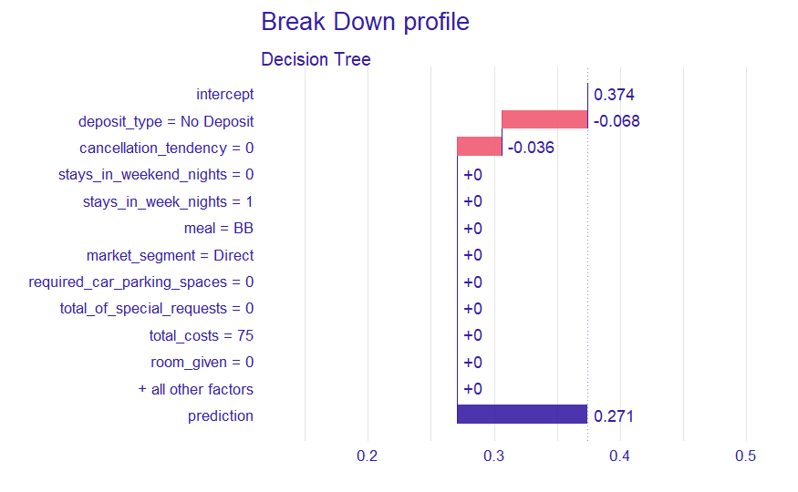

```r
# prediction parts
plot(predict_parts(df_exDT, new_observation = single_row))
```

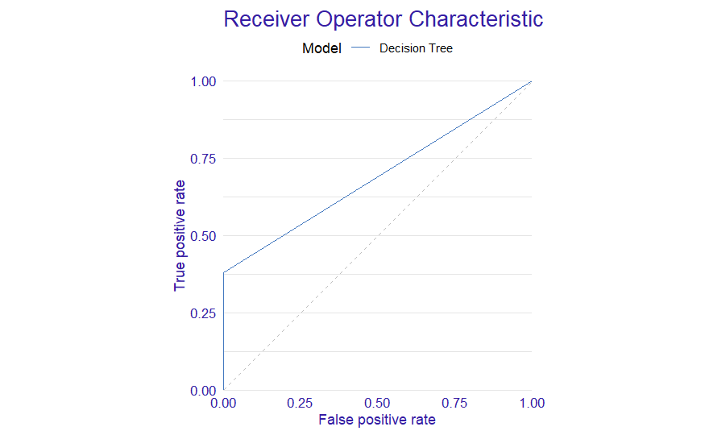

```r
plot(model_performance(df_exDT), geom = "roc")
```

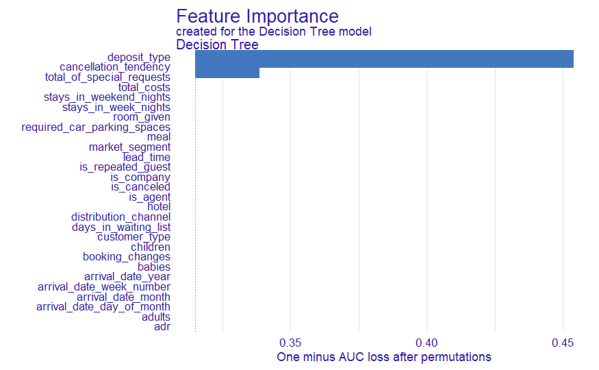

```r
plot(model_parts(df_exDT), show_boxplots = FALSE)
```

# Random Forest

```r
set.seed(45)

#For train data
model.rf = randomForest(is_canceled ~ . -total_costs, data = train_data,
                     keep.forest = TRUE, ntree = 150)

#For train data down
model_down.rf = randomForest(is_canceled ~ . -total_costs, data = train_data_down,
                     keep.forest = TRUE, ntree = 150)
```

```r
#print the train data model
print(model.rf)
```

```
Call:
 randomForest(formula = is_canceled ~ . - total_costs, data = train_data,      keep.forest = TRUE, ntree = 150)
               Type of random forest: classification
                     Number of trees: 150
No. of variables tried at each split: 5

        OOB estimate of  error rate: 13.39%
Confusion matrix:
      0     1 class.error
0 47632  3645   0.0710845
1  7337 23411   0.2386171
```

```r
#print train data down model
print(model_down.rf)
```

```
Call:
 randomForest(formula = is_canceled ~ . - total_costs, data = train_data_down,      keep.forest = TRUE, ntree = 150)
               Type of random forest: classification
                     Number of trees: 150
No. of variables tried at each split: 5

        OOB estimate of  error rate: 15.5%
Confusion matrix:
      0     1 class.error
0 26430  4318   0.1404319
1  5212 25536   0.1695070
```

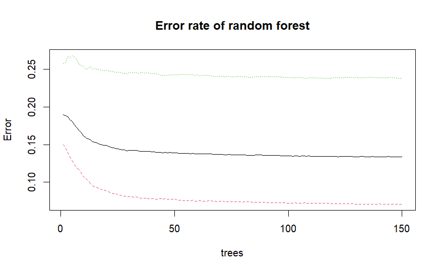

```r
#plot the train data model
plot(model.rf, main = "Error rate of random forest")
```

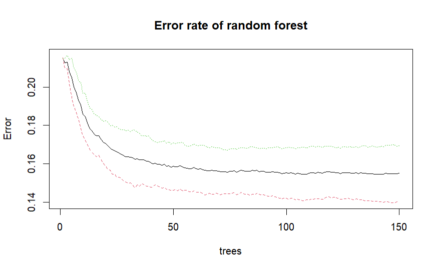

```r
#plot the train data down model
plot(model_down.rf, main = "Error rate of random forest")
```

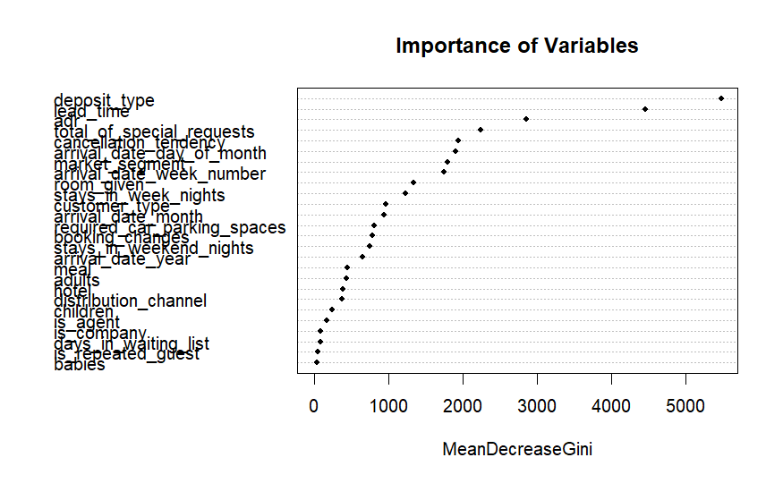

```r
#For train data
varImpPlot(model.rf, pch = 20, main = "Importance of Variables")
```

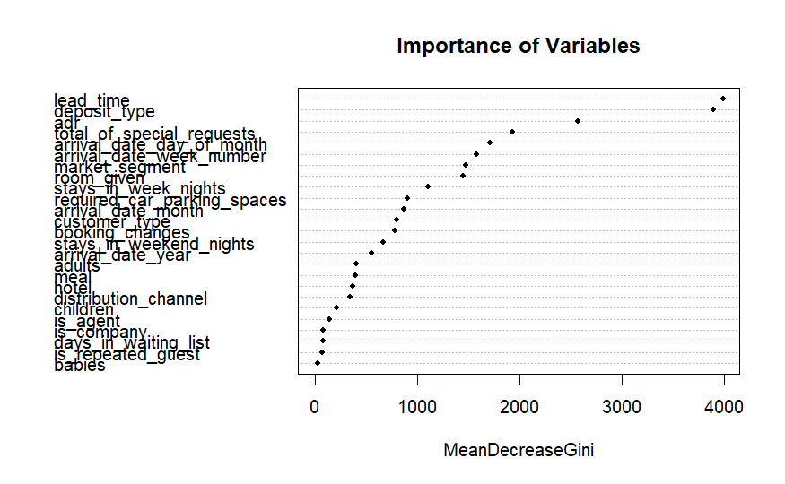

```r
#For train data down
varImpPlot(model_down.rf, pch = 20, main = "Importance of Variables")
```

```r
#For train data
pred_Test_rd = predict(model.rf, test_data[,setdiff(names(test_data),"is_canceled")],
                    type="response",
                    norm.votes=TRUE
)

#For train data down
pred_Test_rd_down = predict(model_down.rf, test_data[,setdiff(names(test_data),"is_canceled")],
                    type="response",
                    norm.votes=TRUE
)


#For train data

tab_Test = table(actual=test_data$is_canceled, predicted=pred_Test_rd);
confusionMatrix(tab_Test, mode = "everything", positive = "1")
```

```
Confusion Matrix and Statistics

      predicted
actual     0     1
     0 20431  1544
     1  3182  9995

               Accuracy : 0.8656
                 95% CI : (0.8619, 0.8691)
    No Information Rate : 0.6717
    P-Value [Acc > NIR] : < 2.2e-16

                  Kappa : 0.7058

 Mcnemar's Test P-Value : < 2.2e-16

            Sensitivity : 0.8662
            Specificity : 0.8652
         Pos Pred Value : 0.7585
         Neg Pred Value : 0.9297
              Precision : 0.7585
                 Recall : 0.8662
                     F1 : 0.8088
             Prevalence : 0.3283
         Detection Rate : 0.2843
   Detection Prevalence : 0.3749
      Balanced Accuracy : 0.8657

       'Positive' Class : 1
```

```r
#For train data down
tab_Test_down = table(actual=test_data$is_canceled, predicted=pred_Test_rd_down);
confusionMatrix(tab_Test_down,mode="everything", positive = "1")
```

```
Confusion Matrix and Statistics

      predicted
actual     0     1
     0 18939  3036
     1  2208 10969

               Accuracy : 0.8508
                 95% CI : (0.8471, 0.8545)
    No Information Rate : 0.6016
    P-Value [Acc > NIR] : < 2.2e-16

                  Kappa : 0.6857

 Mcnemar's Test P-Value : < 2.2e-16

            Sensitivity : 0.7832
            Specificity : 0.8956
         Pos Pred Value : 0.8324
         Neg Pred Value : 0.8618
              Precision : 0.8324
                 Recall : 0.7832
                     F1 : 0.8071
             Prevalence : 0.3984
         Detection Rate : 0.3120
   Detection Prevalence : 0.3749
      Balanced Accuracy : 0.8394

       'Positive' Class : 1
```

```r
AUC_RF_ = auc(as.numeric(test_data$is_canceled), as.numeric(pred_Test_rd))
```

# Dalex Random Forest on train data

```r
df_exRF = explain(model.rf,
                data  = df2,
                y     = df2$is_canceled,
                label = "Random Forest")
```

```
Preparation of a new explainer is initiated
  -> model label       :  Random Forest
  -> data              :  117177  rows  28  cols
  -> data              :  tibble converted into a data.frame
  -> target variable   :  117177  values
  -> predict function  :  yhat.randomForest  will be used (  default  )
  -> predicted values  :  No value for predict function target column. (  default  )
  -> model_info        :  package randomForest , ver. 4.7.1.1 , task classification (  default  )
  -> predicted values  :  numerical, min =  0 , mean =  0.3712343 , max =  1
  -> residual function :  difference between y and yhat (  default  )
  -> residuals         :  numerical, min =  -0.98 , mean =  0.003625968 , max =  1
  A new explainer has been created!
```

```r
# instance level
(single_row = df2[1,])
```

| hotel | is_canceled | lead_time | arrival_date_year | arrival_date_month | arrival_date_week_number | arrival_date_day_of_month | stays_in_weekend_nights | stays_in_week_nights | adults | children | babies | meal | market_segment | distribution_channel | is_repeated_guest | booking_changes | deposit_type | days_in_waiting_list | customer_type | adr | required_car_parking_spaces | total_of_special_requests | is_agent | is_company | total_costs | room_given | cancellation_tendency |
| --- | --- | --- | --- | --- | --- | --- | --- | --- | --- | --- | --- | --- | --- | --- | --- | --- | --- | --- | --- | --- | --- | --- | --- | --- | --- | --- | --- |
| Resort Hotel | 0 | 7 | 2015 | July | 27 | 1 | 0 | 1 | 1 | 0 | 0 | BB | Direct | Direct | 0 | 0 | No Deposit | 0 | Transient | 75 | 0 | 0 | 0 | 0 | 75 | 0 | 0 |

```r
# prediction
df_exRF %>% predict(single_row)
```

```
[1] 0.1733333
```

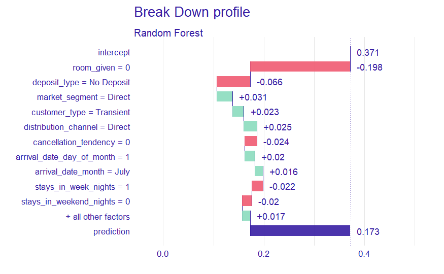

```r
# prediction parts
plot(predict_parts(df_exRF, new_observation = single_row))
```

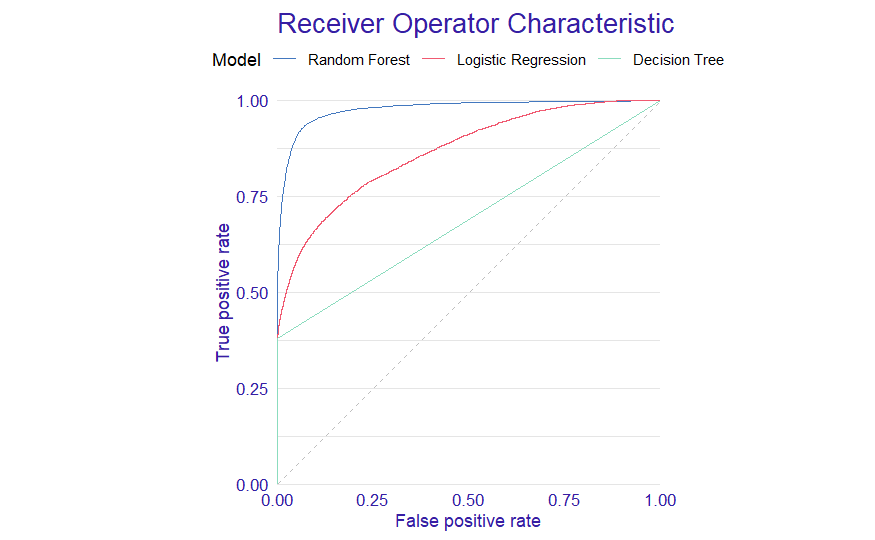

```r
plot(model_performance(df_exLR),
     model_performance(df_exRF),
     model_performance(df_exDT),
     geom = "roc")
```

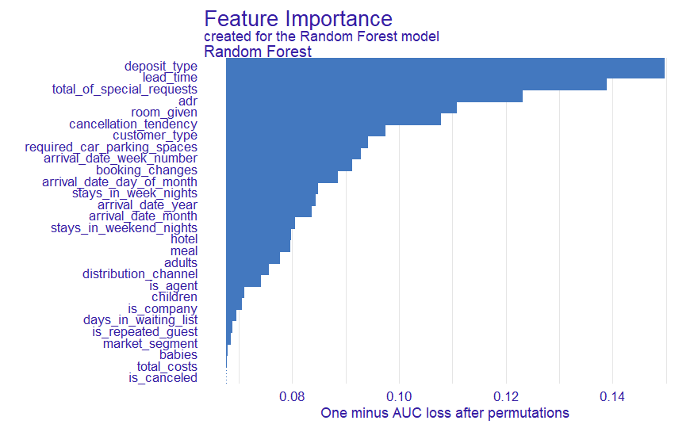

```r
plot(model_parts(df_exRF), show_boxplots = FALSE)
```

# ADR

```r
# Convert some of the numeric variables into factors
df$is_canceled <- as.factor(df$is_canceled)
df$arrival_date_year <- as.factor(df$arrival_date_year)
```

```r
# Rearrange order of the levels of the arrival_date_month factor so they are  in chronological order when plotting them

df$arrival_date_month <- factor(df$arrival_date_month, levels=c("January", "February", "March", "April", "May", "June", "July", "August", "September", "October", "November", "December"))
# remove unused Resort data
df_resort <- subset(df, hotel=="Resort Hotel", select= -c(hotel,country,distribution_channel,is_repeated_guest,previous_cancellations,
previous_bookings_not_canceled,assigned_room_type,booking_changes,deposit_type,is_agent,is_company,days_in_waiting_list))
dim(df_resort)
```

```
[1] 39306    19
```

```r
# remove unused Resort data
df_city <- subset(df, hotel=="City Hotel", select= -c(hotel,country,distribution_channel,is_repeated_guest,previous_cancellations,
previous_bookings_not_canceled,assigned_room_type,booking_changes,deposit_type,is_agent,is_company,days_in_waiting_list))
dim(df_city)
```

```
[1] 77871    19
```

```r
df_resort$arrival_date <- with(df_resort, paste(arrival_date_year, arrival_date_month, arrival_date_day_of_month, sep="-"))
df_resort$arrival_date_formatted <- parse_date_time(df_resort$arrival_date, orders = "ymd")


df_city$arrival_date <- with(df_city, paste(arrival_date_year, arrival_date_month, arrival_date_day_of_month, sep="-"))
df_city$arrival_date_formatted <- parse_date_time(df_city$arrival_date, orders = "ymd")
```

```r
# Descriptive stats
skim(df_resort)
```

```
── Data Summary ────────────────────────
                           Values
Name                       df_resort
Number of rows             39306
Number of columns          21
_______________________
Column type frequency:
  character                5
  factor                   3
  numeric                  12
  POSIXct                  1
________________________
Group variables            None
```

|  | skim_variable | n_missing | complete_rate | min | max | empty | n_unique | whitespace |
| --- | --- | --- | --- | --- | --- | --- | --- | --- |
| 1 | meal | 0 | 1 | 2 | 2 | 0 | 4 | 0 |
| 2 | market_segment | 0 | 1 | 6 | 13 | 0 | 6 | 0 |
| 3 | reserved_room_type | 0 | 1 | 1 | 1 | 0 | 9 | 0 |
| 4 | customer_type | 0 | 1 | 5 | 15 | 0 | 4 | 0 |
| 5 | arrival_date | 0 | 1 | 10 | 17 | 0 | 793 | 0 |

|  | skim_variable | n_missing | complete_rate | ordered | n_unique | top_counts |
| --- | --- | --- | --- | --- | --- | --- |
| 1 | is_canceled | 0 | 1 | FALSE | 2 | 0: 28268, 1: 11038 |
| 2 | arrival_date_year | 0 | 1 | FALSE | 3 | 201: 18184, 201: 13004, 201: 8118 |
| 3 | arrival_date_month | 0 | 1 | FALSE | 12 | Aug: 4849, Jul: 4511, Apr: 3547, May: 3490 |

|  | skim_variable | n_missing | complete_rate | mean | sd | p0 | p25 | p50 | p75 | p100 | hist |
| --- | --- | --- | --- | --- | --- | --- | --- | --- | --- | --- | --- |
| 1 | lead_time | 0 | 1 | 93.43130820 | 97.2254858 | 0.00 | 11 | 59.0 | 155.0000 | 709 | ▇▂▁▁▁ |
| 2 | arrival_date_week_number | 0 | 1 | 27.11746298 | 13.9635547 | 1.00 | 16 | 28.0 | 38.0000 | 53 | ▆▆▇▇▆ |
| 3 | arrival_date_day_of_month | 0 | 1 | 15.81511728 | 8.8872790 | 1.00 | 8 | 16.0 | 24.0000 | 31 | ▇▇▇▆▆ |
| 4 | stays_in_weekend_nights | 0 | 1 | 1.20477790 | 1.1455210 | 0.00 | 0 | 1.0 | 2.0000 | 19 | ▇▁▁▁▁ |
| 5 | stays_in_week_nights | 0 | 1 | 3.16483489 | 2.4493809 | 0.00 | 1 | 3.0 | 5.0000 | 50 | ▇▁▁▁▁ |
| 6 | adults | 0 | 1 | 1.86259095 | 0.4415413 | 1.00 | 2 | 2.0 | 2.0000 | 4 | ▂▇▁▁▁ |
| 7 | children | 0 | 1 | 0.12962398 | 0.4468028 | 0.00 | 0 | 0.0 | 0.0000 | 10 | ▇▁▁▁▁ |
| 8 | babies | 0 | 1 | 0.01401822 | 0.1194990 | 0.00 | 0 | 0.0 | 0.0000 | 2 | ▇▁▁▁▁ |
| 9 | adr | 0 | 1 | 96.77097746 | 60.5939982 | 0.26 | 52 | 76.8 | 126.4075 | 508 | ▇▃▁▁▁ |
| 10 | required_car_parking_spaces | 0 | 1 | 0.13906274 | 0.3521386 | 0.00 | 0 | 0.0 | 0.0000 | 8 | ▇▁▁▁▁ |

[output cut: 2 more lines]

|  | skim_variable | n_missing | complete_rate | min | max | median | n_unique |
| --- | --- | --- | --- | --- | --- | --- | --- |
| 1 | arrival_date_formatted | 0 | 1 | 2015-07-01 | 2017-08-31 | 2016-08-20 | 793 |

```r
skim(df_city)
```

```
── Data Summary ────────────────────────
                           Values
Name                       df_city
Number of rows             77871
Number of columns          21
_______________________
Column type frequency:
  character                5
  factor                   3
  numeric                  12
  POSIXct                  1
________________________
Group variables            None
```

|  | skim_variable | n_missing | complete_rate | min | max | empty | n_unique | whitespace |
| --- | --- | --- | --- | --- | --- | --- | --- | --- |
| 1 | meal | 0 | 1 | 2 | 2 | 0 | 4 | 0 |
| 2 | market_segment | 0 | 1 | 6 | 13 | 0 | 7 | 0 |
| 3 | reserved_room_type | 0 | 1 | 1 | 1 | 0 | 7 | 0 |
| 4 | customer_type | 0 | 1 | 5 | 15 | 0 | 4 | 0 |
| 5 | arrival_date | 0 | 1 | 10 | 17 | 0 | 793 | 0 |

|  | skim_variable | n_missing | complete_rate | ordered | n_unique | top_counts |
| --- | --- | --- | --- | --- | --- | --- |
| 1 | is_canceled | 0 | 1 | FALSE | 2 | 0: 44984, 1: 32887 |
| 2 | arrival_date_year | 0 | 1 | FALSE | 3 | 201: 37443, 201: 27155, 201: 13273 |
| 3 | arrival_date_month | 0 | 1 | FALSE | 12 | Aug: 8824, May: 8102, Jul: 7945, Jun: 7802 |

|  | skim_variable | n_missing | complete_rate | mean | sd | p0 | p25 | p50 | p75 | p100 | hist |
| --- | --- | --- | --- | --- | --- | --- | --- | --- | --- | --- | --- |
| 1 | lead_time | 0 | 1 | 1.109230e+02 | 111.04702046 | 0.0 | 24.0 | 75.00 | 164 | 629 | ▇▂▁▁▁ |
| 2 | arrival_date_week_number | 0 | 1 | 2.714717e+01 | 13.37154040 | 1.0 | 17.0 | 27.00 | 38 | 53 | ▅▇▇▇▅ |
| 3 | arrival_date_day_of_month | 0 | 1 | 1.579451e+01 | 8.73058336 | 1.0 | 8.0 | 16.00 | 23 | 31 | ▇▇▇▇▆ |
| 4 | stays_in_weekend_nights | 0 | 1 | 8.002979e-01 | 0.87853148 | 0.0 | 0.0 | 1.00 | 2 | 10 | ▇▁▁▁▁ |
| 5 | stays_in_week_nights | 0 | 1 | 2.195015e+00 | 1.42674604 | 0.0 | 1.0 | 2.00 | 3 | 25 | ▇▁▁▁▁ |
| 6 | adults | 0 | 1 | 1.865547e+00 | 0.49093851 | 1.0 | 2.0 | 2.00 | 2 | 4 | ▂▇▁▁▁ |
| 7 | children | 0 | 1 | 8.650204e-02 | 0.35916735 | 0.0 | 0.0 | 0.00 | 0 | 3 | ▇▁▁▁▁ |
| 8 | babies | 0 | 1 | 4.751448e-03 | 0.08344714 | 0.0 | 0.0 | 0.00 | 0 | 10 | ▇▁▁▁▁ |
| 9 | adr | 0 | 1 | 1.070197e+02 | 41.89463718 | 0.5 | 80.0 | 100.00 | 126 | 5400 | ▇▁▁▁▁ |
| 10 | required_car_parking_spaces | 0 | 1 | 2.418102e-02 | 0.15436241 | 0.0 | 0.0 | 0.00 | 0 | 3 | ▇▁▁▁▁ |

[output cut: 2 more lines]

|  | skim_variable | n_missing | complete_rate | min | max | median | n_unique |
| --- | --- | --- | --- | --- | --- | --- | --- |
| 1 | arrival_date_formatted | 0 | 1 | 2015-07-01 | 2017-08-31 | 2016-09-15 | 793 |